# Incorporate Alignment Data in PHANTASY

- Configuration of ARIS/F1 with alignment data
- Generate FLAME model with alignment data
- Element-wise overrides alignment configuration for FLAME model generation

Tong Zhang

2021-07-22 (Revised: 2021-07-27)

## ARIS/F1 machine configuration

There're two ways to configure the alignment info:

1. Set *alignment_file* in machine/segment definition file, e.g. *phantasy.ini*, to point to the filepath where the Excel data sheet of all the alignment data resides;
2. [**Only for FLAME model**] Support overriding alignment info by define the following arguments in the config file, e.g. *phantasy.cfg*, under each machine/segment configuration directory, use element name as the section name and the supported keywords, i.e. *align_dx*, *align_dy*, *align_pitch*, *align_roll*, *align_yaw*;
3. As of now, only FLAME model is supported.

### Segment configuration file

Define *alignment_file* with the path of the Excel file for alignment data.

The Excel data sheet defines 6D alignemnt data for each device with its name as the first column, right followed after alignment errors in pitch, roll, yaw, dx, dy, dz and timestamp when the row of data is created.

```python
# Configuration of the machine and segment, e.g. ARIS/F1
!cat ../../phantasy.ini
```

```
[COMMON]
segments = F1
default_segment = F1
root_data_dir = ~/phantasy_data

[F1]
controls_protocol = EPICS
s_begin = 100
s_end = 146.931962
loop = 0
model = flame
model_data_dir = model_data
cfs_url = ./presp/channels.csv
cfs_tag = F1
cfs_property_names = *
settings_file = ./presp/settings.json
layout_file = ./presp/layout.csv
config_file = ./presp/phantasy.cfg
alignment_file = ./presp/ARIS_F1_misalignment_sheet_example.xlsx
```

### Investigate alignment info

```python
from phantasy import MachinePortal
```

```python
mp = MachinePortal("ARIS", "F1")
lat = mp.work_lattice_conf
```

```
[09:11:20.920] INFO: phantasy.library.operation.core: Load new machine: 'ARIS', segment: 'F1'
[09:11:20.921] INFO: phantasy.library.parser.config: Importing ARIS from /home/tong/Dropbox/phantasy-project/phantasy-machines/ARIS
[09:11:20.923] INFO: phantasy.library.parser.config: Loading machine configuration from /home/tong/Dropbox/phantasy-project/phantasy-machines/ARIS/phantasy.ini
[09:11:20.924] INFO: phantasy.library.operation.lattice: Loading segment: 'F1'
[09:11:20.927] WARNING: phantasy.library.operation.lattice: Default UNICORN policy will be applied.
[09:11:20.943] INFO: phantasy.library.operation.lattice: Read alignment data from /home/tong/Dropbox/phantasy-project/phantasy-machines/ARIS/presp/ARIS_F1_misalignment_sheet_example.xlsx.
[09:11:20.945] WARNING: phantasy.library.operation.lattice: Default device polarity will be applied.
[09:11:20.947] INFO: phantasy.library.operation.lattice: Loading PV data from CSV/SQLite: /home/tong/Dropbox/phantasy-project/phantasy-machines/ARIS/presp/channels.csv
[09:11:20.949] INFO: phantasy.library.pv.datasource: Set source to be CSV table: channels.csv.
[09:11:20.968] INFO: phantasy.library.operation.lattice: Model data directory: /home/tong/phantasy_data/20210727/model_data/data_091120
[09:11:20.969] INFO: phantasy.library.operation.lattice: Found 267 PVs in 'F1'.
[09:11:21.100] INFO: phantasy.library.operation.lattice: 'F1' has 50 elements
```

```python
q0 = mp.get_elements(type='QUAD')[0]
q0
```

```
FS_F1S1:Q_D1013 [QUAD] @ sb=0.988163
```

```python
# alignment existing as one static attribute of the device, under which 6D alignment data is reachable
q0.alignment
```

```
pitch                 0.1
roll                  0.2
yaw                   0.3
dx                  0.001
dy                  0.002
dz                  0.003
ts       2021-07-20 17:05
Name: FS_F1S1:Q_D1013, dtype: object
```

```python
q0.alignment.dx
```

```
0.001
```

### Override alignment configuration for FLAME model

For example: overwrite the alignment info of quad **FS_F1S1:Q_D1013**, by defining in *phantasy.cfg*, for FLAME model only.

**!This will not change .alignment attribute value!**

```python
!tail -10 ../phantasy.cfg
```

```
[QUAD_FSQ10]
length:0.819979

[FS_F1S1:Q_D1013]
#overwrite alignment error
align_dx: 0.002
align_dy: 0.003
align_pitch: 0
align_roll: 0
align_yaw: 0
```

```python
# Generate FLAME model
latfile, fm = lat.run()
# latfile is FLAME lattice file could work with or distribute.
# Or *fm* is ready to work with
```

```
[09:11:21.294] INFO: phantasy.library.lattice.flame: Alignment error: dx of FS_F1S1:Q_D1013 is 0.002 m.
[09:11:21.297] INFO: phantasy.library.lattice.flame: Alignment error: dy of FS_F1S1:Q_D1013 is 0.003 m.
[09:11:21.298] INFO: phantasy.library.lattice.flame: Alignment error: pitch of FS_F1S1:Q_D1013 is 0 deg.
[09:11:21.298] INFO: phantasy.library.lattice.flame: Alignment error: roll of FS_F1S1:Q_D1013 is 0 deg.
[09:11:21.298] INFO: phantasy.library.lattice.flame: Alignment error: yaw of FS_F1S1:Q_D1013 is 0 deg.
[09:11:21.302] INFO: phantasy.library.lattice.flame: Load alignment error [  FS_F1S1:Q_D1013   ]: {'dx': 0.002, 'dy': 0.003, 'pitch': 0.0, 'roll': 0.0, 'yaw': 0.0}
[09:11:21.324] ERROR: flame_utils.core.model: expected str, bytes or os.PathLike object, not NoneType
[09:11:21.325] WARNING: flame_utils.core.model: ModelFlame: Lattice file is not valid, do it manually.
```

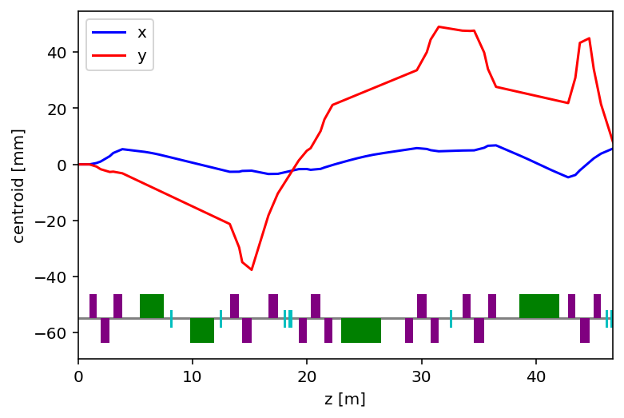

```python
from flame_utils import hplot
hplot('xcen', 'ycen', machine=fm)
```